# Uber Ride Cost Regression

I'm Jaya Prakash and this project is a part of my journey in mastering data manipulation and machine learning.

## Problem Description

The goal of this project is to develop a regression model that accurately determines the cost of Uber rides. The data utilized in this project is obtained from Kaggle - https://www.kaggle.com/datasets/yasserh/uber-fares-dataset

## Workflow

1. Data Preparation
2. Exploratory Data Analysis
3. Feature Engineering
4. Model Selection
5. Hyper Parameter Tuning
6. Model Evaluation
7. Export Best Model

```python
# Import all the neccessary tools for EDA
import pandas as pd
import numpy as np
import matplotlib.pyplot as plt
import seaborn as sns
```

# 1. Data Preparation

```python
data = pd.read_csv("uber.csv")
```

```python
data.head()
```

|  | Unnamed: 0 | key | fare_amount | pickup_datetime | pickup_longitude | pickup_latitude | dropoff_longitude | dropoff_latitude | passenger_count |
| --- | --- | --- | --- | --- | --- | --- | --- | --- | --- |
| 0 | 24238194 | 2015-05-07 19:52:06.0000003 | 7.5 | 2015-05-07 19:52:06 UTC | -73.999817 | 40.738354 | -73.999512 | 40.723217 | 1 |
| 1 | 27835199 | 2009-07-17 20:04:56.0000002 | 7.7 | 2009-07-17 20:04:56 UTC | -73.994355 | 40.728225 | -73.994710 | 40.750325 | 1 |
| 2 | 44984355 | 2009-08-24 21:45:00.00000061 | 12.9 | 2009-08-24 21:45:00 UTC | -74.005043 | 40.740770 | -73.962565 | 40.772647 | 1 |
| 3 | 25894730 | 2009-06-26 08:22:21.0000001 | 5.3 | 2009-06-26 08:22:21 UTC | -73.976124 | 40.790844 | -73.965316 | 40.803349 | 3 |
| 4 | 17610152 | 2014-08-28 17:47:00.000000188 | 16.0 | 2014-08-28 17:47:00 UTC | -73.925023 | 40.744085 | -73.973082 | 40.761247 | 5 |

```python
data.info()
```

```
<class 'pandas.core.frame.DataFrame'>
RangeIndex: 200000 entries, 0 to 199999
Data columns (total 9 columns):
 #   Column             Non-Null Count   Dtype
---  ------             --------------   -----
 0   Unnamed: 0         200000 non-null  int64
 1   key                200000 non-null  object
 2   fare_amount        200000 non-null  float64
 3   pickup_datetime    200000 non-null  object
 4   pickup_longitude   200000 non-null  float64
 5   pickup_latitude    200000 non-null  float64
 6   dropoff_longitude  199999 non-null  float64
 7   dropoff_latitude   199999 non-null  float64
 8   passenger_count    200000 non-null  int64
dtypes: float64(5), int64(2), object(2)
memory usage: 13.7+ MB
```

```python
data.isna().sum()
```

```
Unnamed: 0           0
key                  0
fare_amount          0
pickup_datetime      0
pickup_longitude     0
pickup_latitude      0
dropoff_longitude    1
dropoff_latitude     1
passenger_count      0
dtype: int64
```

```python
for column in data.columns:
    print(data[column].value_counts())
```

```
24238194    1
23286231    1
45197665    1
30631497    1
7869264     1
           ..
53467014    1
15557161    1
11971041    1
6135974     1
11951496    1
Name: Unnamed: 0, Length: 200000, dtype: int64
2015-05-07 19:52:06.0000003      1
2012-10-14 22:58:00.00000051     1
2013-09-06 10:59:00.00000086     1
2013-12-27 20:23:50.0000001      1
2010-07-22 18:55:00.000000151    1
                                ..
2010-06-28 11:17:41.0000005      1
2010-12-01 12:58:32.0000001      1
2013-05-12 21:10:21.0000003      1
2014-08-09 16:03:54.0000002      1
2010-05-15 04:08:00.00000076     1
Name: key, Length: 200000, dtype: int64
6.50      9684
4.50      8247
8.50      7521
5.70      5858
5.30      5838
          ...
140.25       1
190.00       1
45.16        1
28.20        1
89.10        1
Name: fare_amount, Length: 1244, dtype: int64
2014-04-13 18:19:00 UTC    4
2010-03-14 12:00:00 UTC    4
2009-02-12 12:46:00 UTC    4
2011-02-18 18:55:00 UTC    3
```

[output cut: 50 more lines]

```
40.820070       1
40.656993       1
40.776530       1
40.783642       1
40.768793       1
Name: dropoff_latitude, Length: 90585, dtype: int64
1      138425
2       29428
5       14009
3        8881
4        4276
6        4271
0         709
208         1
Name: passenger_count, dtype: int64
```

```python
data.fare_amount.sort_values()
```

```
111589    -52.00
98875     -52.00
164056    -50.50
89322     -49.57
92063     -23.70
           ...
197493    230.00
71715     250.00
185325    275.00
4292      350.00
170081    499.00
Name: fare_amount, Length: 200000, dtype: float64
```

```python
data.pickup_longitude.sort_values()
```

```
75851    -1340.648410
144253    -768.550000
4949      -748.016667
199936    -736.400000
103745    -736.216667
             ...
68551       40.801212
184570      40.803672
185317      40.806012
51546       40.808425
91422       57.418457
Name: pickup_longitude, Length: 200000, dtype: float64
```

(This still leaves out a few outliers, that are probably errors in data collection. But due to the volume of the data, let us ignore them.)

```python
for column in ["pickup_longitude", "dropoff_longitude"]:
    data.drop(data.loc[(data[column] < -180) | (data[column] > 180)].index, inplace=True)
for column in ["pickup_latitude", "dropoff_latitude"]:
    data.drop(data.loc[(data[column] < -90) | (data[column] > 90)].index, inplace=True)
data.drop(data.loc[(data["passenger_count"] > 6) | (data["passenger_count"] == 0)].index, inplace=True)
data.drop(data.loc[(data["fare_amount"] <= 0) | (data["fare_amount"] > 200)].index, inplace=True)
data.dropna(inplace=True)
data.reset_index(drop=True, inplace=True)
```

Change the unnamed column to "id" and drop the key columns as it is redundant (Since pickup datetime is already provided, and we have "id" column for unique identification of data cells.)

```python
data.rename(columns = {"Unnamed: 0":"id"}, inplace=True)
data.drop(["key"], axis=1, inplace=True)
```

```python
data.head()
```

|  | id | fare_amount | pickup_datetime | pickup_longitude | pickup_latitude | dropoff_longitude | dropoff_latitude | passenger_count |
| --- | --- | --- | --- | --- | --- | --- | --- | --- |
| 0 | 24238194 | 7.5 | 2015-05-07 19:52:06 UTC | -73.999817 | 40.738354 | -73.999512 | 40.723217 | 1 |
| 1 | 27835199 | 7.7 | 2009-07-17 20:04:56 UTC | -73.994355 | 40.728225 | -73.994710 | 40.750325 | 1 |
| 2 | 44984355 | 12.9 | 2009-08-24 21:45:00 UTC | -74.005043 | 40.740770 | -73.962565 | 40.772647 | 1 |
| 3 | 25894730 | 5.3 | 2009-06-26 08:22:21 UTC | -73.976124 | 40.790844 | -73.965316 | 40.803349 | 3 |
| 4 | 17610152 | 16.0 | 2014-08-28 17:47:00 UTC | -73.925023 | 40.744085 | -73.973082 | 40.761247 | 5 |

Convert the pickup_datetime into a day, month, year and time column. (Converting the time into an integer format.)

Also create a distance column from the longitudes and latitudes columns.

```python
def pre_process(data):
    new_data = data.copy()
    year_list = []
    month_list = []
    day_list = []
    time_list = []
    distance_list = []
    i = 0
    while i < len(new_data.pickup_datetime):
        date = new_data.pickup_datetime[i].split(" ")[0]
        time = new_data.pickup_datetime[i].split(" ")[1]
        year = int(date.split("-")[0])
        month = int(date.split("-")[1])
        day = int(date.split("-")[2])
        time = int(time.split(":")[0])*3600 + int(time.split(":")[1])*60 + int(time.split(":")[2])
        x = abs(new_data.pickup_longitude[i] - new_data.dropoff_longitude[i])
        y = abs(new_data.pickup_latitude[i] - new_data.dropoff_latitude[i])
        distance = (x**2 + y**2)**0.5
        year_list.append(year)
        month_list.append(month)
        day_list.append(day)
        time_list.append(time)
        distance_list.append(distance)
        i += 1
    new_data["year"], new_data["month"], new_data["day"], new_data["time"], new_data["distance"] = year_list, month_list, day_list, time_list, distance_list
    new_data.drop(["pickup_datetime"], axis=1, inplace=True)
    return new_data
```

```python
%%time
processed_data = pre_process(data)
```

```
CPU times: total: 17.8 s
Wall time: 17.8 s
```

```python
processed_data.head()
```

|  | id | fare_amount | pickup_longitude | pickup_latitude | dropoff_longitude | dropoff_latitude | passenger_count | year | month | day | time | distance |
| --- | --- | --- | --- | --- | --- | --- | --- | --- | --- | --- | --- | --- |
| 0 | 24238194 | 7.5 | -73.999817 | 40.738354 | -73.999512 | 40.723217 | 1 | 2015 | 5 | 7 | 71526 | 0.015140 |
| 1 | 27835199 | 7.7 | -73.994355 | 40.728225 | -73.994710 | 40.750325 | 1 | 2009 | 7 | 17 | 72296 | 0.022103 |
| 2 | 44984355 | 12.9 | -74.005043 | 40.740770 | -73.962565 | 40.772647 | 1 | 2009 | 8 | 24 | 78300 | 0.053109 |
| 3 | 25894730 | 5.3 | -73.976124 | 40.790844 | -73.965316 | 40.803349 | 3 | 2009 | 6 | 26 | 30141 | 0.016528 |
| 4 | 17610152 | 16.0 | -73.925023 | 40.744085 | -73.973082 | 40.761247 | 5 | 2014 | 8 | 28 | 64020 | 0.051031 |

```python
processed_data.describe()
```

|  | id | fare_amount | pickup_longitude | pickup_latitude | dropoff_longitude | dropoff_latitude | passenger_count | year | month | day | time | distance |
| --- | --- | --- | --- | --- | --- | --- | --- | --- | --- | --- | --- | --- |
| count | 1.992490e+05 | 199249.000000 | 199249.000000 | 199249.000000 | 199249.000000 | 199249.000000 | 199249.000000 | 199249.000000 | 199249.000000 | 199249.000000 | 199249.000000 | 199249.000000 |
| mean | 2.771574e+07 | 11.359585 | -72.505237 | 39.919757 | -72.515467 | 39.924069 | 1.689449 | 2011.743662 | 6.283424 | 15.705700 | 50362.665384 | 0.202409 |
| std | 1.601412e+07 | 9.750854 | 10.438634 | 6.125905 | 10.399418 | 6.112450 | 1.305401 | 1.859080 | 3.438472 | 8.686948 | 23481.550273 | 3.721349 |
| min | 1.000000e+00 | 0.010000 | -93.824668 | -74.015515 | -75.458979 | -74.015750 | 1.000000 | 2009.000000 | 1.000000 | 1.000000 | 0.000000 | 0.000000 |
| 25% | 1.382629e+07 | 6.000000 | -73.992064 | 40.734797 | -73.991409 | 40.733829 | 1.000000 | 2010.000000 | 3.000000 | 8.000000 | 33856.000000 | 0.012435 |
| 50% | 2.775601e+07 | 8.500000 | -73.981825 | 40.752583 | -73.980095 | 40.753042 | 1.000000 | 2012.000000 | 6.000000 | 16.000000 | 52680.000000 | 0.021495 |
| 75% | 4.156019e+07 | 12.500000 | -73.967165 | 40.767155 | -73.963664 | 40.767995 | 2.000000 | 2013.000000 | 9.000000 | 23.000000 | 70260.000000 | 0.038343 |
| max | 5.542357e+07 | 200.000000 | 40.808425 | 48.018760 | 40.831932 | 45.031598 | 6.000000 | 2015.000000 | 12.000000 | 31.000000 | 86399.000000 | 85.699229 |

```python
processed_data.loc[processed_data["fare_amount"] > 100]
```

|  | id | fare_amount | pickup_longitude | pickup_latitude | dropoff_longitude | dropoff_latitude | passenger_count | year | month | day | time | distance |
| --- | --- | --- | --- | --- | --- | --- | --- | --- | --- | --- | --- | --- |
| 2049 | 31333682 | 113.66 | -73.951227 | 40.778753 | -73.949938 | 40.778149 | 1 | 2014 | 11 | 1 | 31359 | 0.001423 |
| 5952 | 28138818 | 105.00 | -73.752265 | 40.923303 | -73.752270 | 40.923303 | 1 | 2011 | 5 | 6 | 2400 | 0.000005 |
| 6597 | 28579349 | 137.00 | 0.000000 | 0.000000 | 0.000000 | 0.000000 | 1 | 2013 | 5 | 3 | 36300 | 0.000000 |
| 9036 | 33046347 | 126.10 | -73.788657 | 40.640643 | -74.001350 | 41.048048 | 1 | 2011 | 6 | 13 | 56760 | 0.459584 |
| 11266 | 52300154 | 113.00 | -74.468770 | 40.476630 | -74.468772 | 40.476630 | 2 | 2013 | 12 | 6 | 8220 | 0.000002 |
| ... | ... | ... | ... | ... | ... | ... | ... | ... | ... | ... | ... | ... |
| 187527 | 21519159 | 165.00 | -73.219710 | 40.803600 | -73.219702 | 40.803599 | 1 | 2012 | 8 | 17 | 45368 | 0.000008 |
| 190055 | 19562599 | 120.30 | -73.788095 | 40.642330 | -73.976730 | 40.931132 | 3 | 2012 | 9 | 3 | 1260 | 0.344949 |
| 193726 | 34209729 | 130.25 | -73.982272 | 40.763447 | -74.177182 | 40.695032 | 1 | 2013 | 11 | 22 | 47220 | 0.206568 |
| 195873 | 53659256 | 109.00 | -73.984697 | 40.749896 | -74.045293 | 40.973143 | 2 | 2014 | 2 | 2 | 17025 | 0.231325 |
| 195904 | 13085828 | 200.00 | -73.952994 | 40.736298 | -73.952994 | 40.736298 | 1 | 2010 | 8 | 19 | 60765 | 0.000000 |

77 rows × 12 columns

# 2. Exploratory Data Analysis

Let us compare the different features of our data with the fare_amount to get more intuitive understanding of the data.

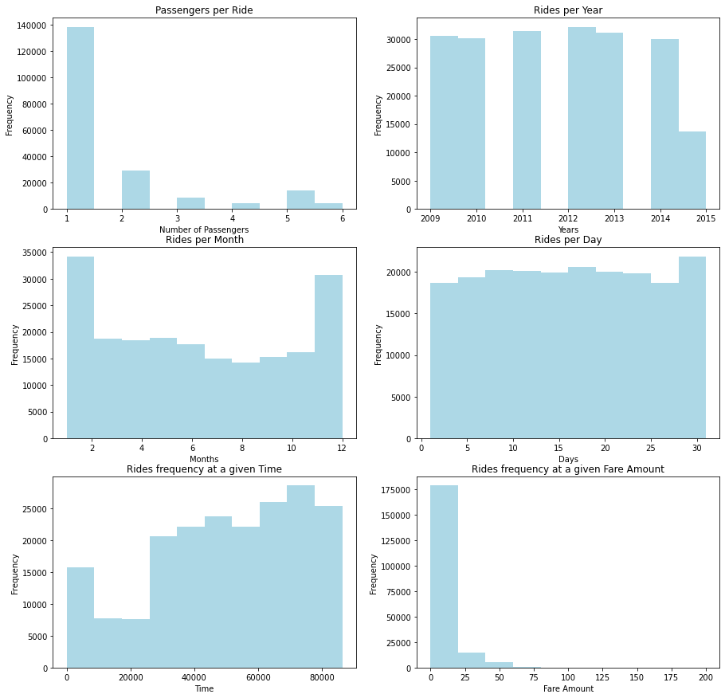

```python
fig, ax = plt.subplots(3, 2, figsize=(15,15))
ax[0, 0].hist(processed_data.passenger_count, color=["lightblue"])
ax[0, 0].set_xlabel("Number of Passengers")
ax[0, 0].set_ylabel("Frequency")
ax[0, 0].set_title("Passengers per Ride")

ax[0, 1].hist(processed_data.year, color=["lightblue"])
ax[0, 1].set_xlabel("Years")
ax[0, 1].set_ylabel("Frequency")
ax[0, 1].set_title("Rides per Year")

ax[1, 0].hist(processed_data.month, color=["lightblue"])
ax[1, 0].set_xlabel("Months")
ax[1, 0].set_ylabel("Frequency")
ax[1, 0].set_title("Rides per Month")

ax[1, 1].hist(processed_data.day, color=["lightblue"])
ax[1, 1].set_xlabel("Days")
ax[1, 1].set_ylabel("Frequency")
ax[1, 1].set_title("Rides per Day")

ax[2, 0].hist(processed_data.time, color=["lightblue"])
ax[2, 0].set_xlabel("Time")
ax[2, 0].set_ylabel("Frequency")
ax[2, 0].set_title("Rides frequency at a given Time")

ax[2, 1].hist(processed_data.fare_amount, color=["lightblue"])
ax[2, 1].set_xlabel("Fare Amount")
ax[2, 1].set_ylabel("Frequency")
ax[2, 1].set_title("Rides frequency at a given Fare Amount")
```

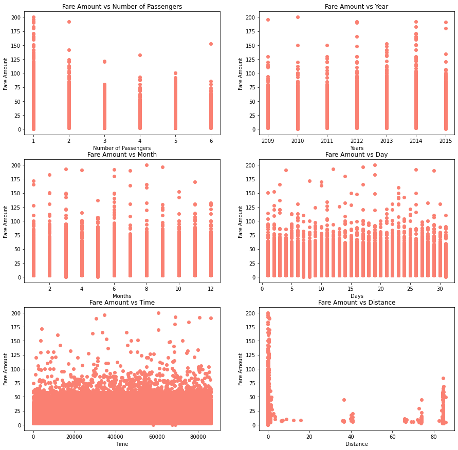

```python
fig, ax = plt.subplots(3, 2, figsize=(15,15))
ax[0, 0].scatter(processed_data.passenger_count, processed_data.fare_amount, color=["salmon"])
ax[0, 0].set_xlabel("Number of Passengers")
ax[0, 0].set_ylabel("Fare Amount")
ax[0, 0].set_title("Fare Amount vs Number of Passengers")

ax[0, 1].scatter(processed_data.year, processed_data.fare_amount, color=["salmon"])
ax[0, 1].set_xlabel("Years")
ax[0, 1].set_ylabel("Fare Amount")
ax[0, 1].set_title("Fare Amount vs Year")

ax[1, 0].scatter(processed_data.month, processed_data.fare_amount, color=["salmon"])
ax[1, 0].set_xlabel("Months")
ax[1, 0].set_ylabel("Fare Amount")
ax[1, 0].set_title("Fare Amount vs Month")

ax[1, 1].scatter(processed_data.day, processed_data.fare_amount, color=["salmon"])
ax[1, 1].set_xlabel("Days")
ax[1, 1].set_ylabel("Fare Amount")
ax[1, 1].set_title("Fare Amount vs Day")

ax[2, 0].scatter(processed_data.time, processed_data.fare_amount, color=["salmon"])
ax[2, 0].set_xlabel("Time")
ax[2, 0].set_ylabel("Fare Amount")
ax[2, 0].set_title("Fare Amount vs Time")

ax[2, 1].scatter(processed_data.distance, processed_data.fare_amount, color=["salmon"])
ax[2, 1].set_xlabel("Distance")
ax[2, 1].set_ylabel("Fare Amount")
ax[2, 1].set_title("Fare Amount vs Distance")
```

# 3. Feature Engineering

```python
from sklearn.model_selection import train_test_split

train_X, test_X, train_y, test_y = train_test_split(processed_data.drop(["fare_amount"], axis=1), processed_data["fare_amount"], test_size=0.2, random_state=7)
```

```python
processed_data["fare_amount"]
```

```
0          7.5
1          7.7
2         12.9
3          5.3
4         16.0
          ...
199244     3.0
199245     7.5
199246    30.9
199247    14.5
199248    14.1
Name: fare_amount, Length: 199249, dtype: float64
```

# 4. Model Selection

```python
%%time
from sklearn.ensemble import RandomForestRegressor

rfr = RandomForestRegressor()
rfr.fit(train_X, train_y)
```

```
CPU times: total: 2min 52s
Wall time: 2min 55s
```

```
RandomForestRegressor()
```

```python
%%time
rfr_pred = rfr.predict(test_X)
rfr_score = rfr.score(test_X, test_y)
rfr_score
```

```
CPU times: total: 2.95 s
Wall time: 2.96 s
```

```
0.8179917412241723
```

We select the RandomForestRegressor as our model and proceed to hyperparameter tuning.

# 5. Hyper Parameter Tuning

```python
from sklearn.model_selection import GridSearchCV
parameters = {"n_estimators": [100, 250, 500, 1000]}

grid_cv = GridSearchCV(estimator=rfr, param_grid=parameters, cv=5, verbose=3)
```

```python
%%time
grid_cv.fit(train_X[:10000], train_y[:10000])
```

```
Fitting 5 folds for each of 4 candidates, totalling 20 fits
[CV 1/5] END ..................n_estimators=100;, score=0.745 total time=   5.4s
[CV 2/5] END ..................n_estimators=100;, score=0.824 total time=   5.5s
[CV 3/5] END ..................n_estimators=100;, score=0.735 total time=   5.4s
[CV 4/5] END ..................n_estimators=100;, score=0.810 total time=   5.5s
[CV 5/5] END ..................n_estimators=100;, score=0.773 total time=   5.3s
[CV 1/5] END ..................n_estimators=250;, score=0.748 total time=  13.7s
[CV 2/5] END ..................n_estimators=250;, score=0.822 total time=  13.9s
[CV 3/5] END ..................n_estimators=250;, score=0.738 total time=  13.7s
[CV 4/5] END ..................n_estimators=250;, score=0.816 total time=  13.9s
[CV 5/5] END ..................n_estimators=250;, score=0.781 total time=  13.4s
[CV 1/5] END ..................n_estimators=500;, score=0.750 total time=  27.5s
[CV 2/5] END ..................n_estimators=500;, score=0.821 total time=  27.9s
[CV 3/5] END ..................n_estimators=500;, score=0.737 total time=  27.5s
[CV 4/5] END ..................n_estimators=500;, score=0.817 total time=  27.9s
[CV 5/5] END ..................n_estimators=500;, score=0.780 total time=  27.0s
[CV 1/5] END .................n_estimators=1000;, score=0.750 total time=  55.1s
[CV 2/5] END .................n_estimators=1000;, score=0.823 total time=  55.8s
[CV 3/5] END .................n_estimators=1000;, score=0.737 total time=  55.2s
[CV 4/5] END .................n_estimators=1000;, score=0.817 total time=  56.0s
[CV 5/5] END .................n_estimators=1000;, score=0.779 total time=  54.0s
CPU times: total: 9min 43s
Wall time: 9min 43s
```

```
GridSearchCV(cv=5, estimator=RandomForestRegressor(),
             param_grid={'n_estimators': [100, 250, 500, 1000]}, verbose=3)
```

```python
grid_cv.best_score_
```

```
0.7812236151900849
```

```python
%%time
grid_cv2 = GridSearchCV(estimator=rfr, param_grid=parameters, cv=2, verbose=3)
grid_cv2.fit(train_X[:50000], train_y[:50000])
```

```
Fitting 2 folds for each of 4 candidates, totalling 8 fits
[CV 1/2] END ..................n_estimators=100;, score=0.792 total time=  20.8s
[CV 2/2] END ..................n_estimators=100;, score=0.782 total time=  20.7s
[CV 1/2] END ..................n_estimators=250;, score=0.794 total time=  52.1s
[CV 2/2] END ..................n_estimators=250;, score=0.779 total time=  51.9s
[CV 1/2] END ..................n_estimators=500;, score=0.791 total time= 1.7min
[CV 2/2] END ..................n_estimators=500;, score=0.779 total time= 1.7min
[CV 1/2] END .................n_estimators=1000;, score=0.792 total time= 3.5min
[CV 2/2] END .................n_estimators=1000;, score=0.780 total time= 3.5min
CPU times: total: 13min 37s
Wall time: 13min 37s
```

```
GridSearchCV(cv=2, estimator=RandomForestRegressor(),
             param_grid={'n_estimators': [100, 250, 500, 1000]}, verbose=3)
```

```python
grid_cv2.best_score_
```

```
0.7871638937020132
```

```python
%%time
grid_cv3 = GridSearchCV(estimator=rfr, param_grid={"n_estimators":[200]}, cv=2, verbose=3)
grid_cv3.fit(train_X, train_y)
```

```
Fitting 2 folds for each of 1 candidates, totalling 2 fits
[CV 1/2] END ..................n_estimators=200;, score=0.804 total time= 2.6min
[CV 2/2] END ..................n_estimators=200;, score=0.810 total time= 2.6min
CPU times: total: 10min 52s
Wall time: 10min 52s
```

```
GridSearchCV(cv=2, estimator=RandomForestRegressor(),
             param_grid={'n_estimators': [200]}, verbose=3)
```

```python
grid_cv3.best_score_
```

```
0.8067727579313185
```

# 6. Model Evaluation

```python
grid_cv3.score(test_X, test_y)
```

```
0.8200484065493455
```

Final model parameters are {"n_estimators": 200}

We fit the final model and test it once more.

```python
final_model = RandomForestRegressor(random_state=7, n_estimators=200)
final_model.fit(train_X, train_y)
final_model.score(test_X, test_y)
```

```
0.8196440323273088
```

# 7. Model Submission

```python
scores = final_model.predict(test_X)
submission = pd.DataFrame(test_X["id"])
submission["predicted_fare_amount"] = scores
```

```python
submission.head()
```

|  | id | predicted_fare_amount |
| --- | --- | --- |
| 89094 | 47502953 | 10.4935 |
| 45791 | 39239031 | 4.8755 |
| 114037 | 51374191 | 16.3325 |
| 49701 | 26644000 | 8.4980 |
| 84190 | 41093728 | 6.1175 |